# Generador de Números pseudoaleatorios

Lizeth Moreno

14 de abril de 2019

Facultad de Ciencias, Ingeniería Matemática, Escuela Politécnica Nacional.

** SIMULACIÓN **

### DEBER1

## Ejercicio 3.3 (para entregar)

Considera el generador congruencial definido por:

$x_{n+1}=(65x_{n}+1)mod 2048$

$U_{n+1}=\frac{X_{n+1}}{{2048}}, n=0,1,...$

#### a.Indicar razonadamente si es de ciclo mÃ¡ximo.

El generador congruencial esta dado para : $a=65$ $m=2048$ $c=1$ Este generador congruencial tendrá su periodo máximo en $p=2048$ si y solo si se cumplen tres condiciones según el Teorema 1. gcd(m,c) = 1

```r
library("numbers")
m<-2048
c<-1
GCD(m,c)
```

```
## [1] 1
```

2. $a-1=64$ mÃºltiplo de los factores primos de 20481.

```r
library("numbers")
m<-2048
m
```

```
## [1] 2048
```

```r
#primeFactors(n)
```

De tal forma quÃ© se verifica que $64$ es múltiplo de $2$

3.$2048$ múltiplo de 4 y $64$ también lo es.

```r
2048/4
```

```
## [1] 512
```

Así, $p=2048$ se concluye que el ciclo máximo.

#### b.Generar $1000$ valores tomando como semilla inicial el nº de grupo multiplicado por $100$ y obtener el tiempo de CPU. Representar gráficamente el ajuste a la densidad teórica y realizar el correspondiente contraste de Kolmogorov-Smirnov.

Usando código de Rstudio para calcular el tiempo de CPU se tiene:

```r
n_g<-2
a<-65
c<-1
m<-2048
initRANDC <- function(semilla=as.numeric(Sys.time()), a=65, c=1, m=2048) {
  .semilla <<- as.double(semilla) %% m  #C?lculos en doble precisi?n
  .a <<- a
  .c <<- c
  .m <<- m
  return(invisible(list(semilla=.semilla,a=.a,c=.c,m=.m))) #print(initRANDC())
}
initRANDC()
RANDC <- function() {
  if (!exists(".semilla", envir=globalenv())) initRANDC()
  .semilla <<- (.a * .semilla + .c) %% .m
  return(.semilla/.m)
}
RANDCN <- function(n=1000) {
  x <- numeric(n)
  for(i in 1:n) x[i]<-RANDC()
  return(replicate(n,RANDC()))
}
system.time(RANDCN(n=1000))
```

```
##    user  system elapsed
##    0.06    0.00    0.06
```

Su represetnación gráfica del ajuste la densidad teórica es:

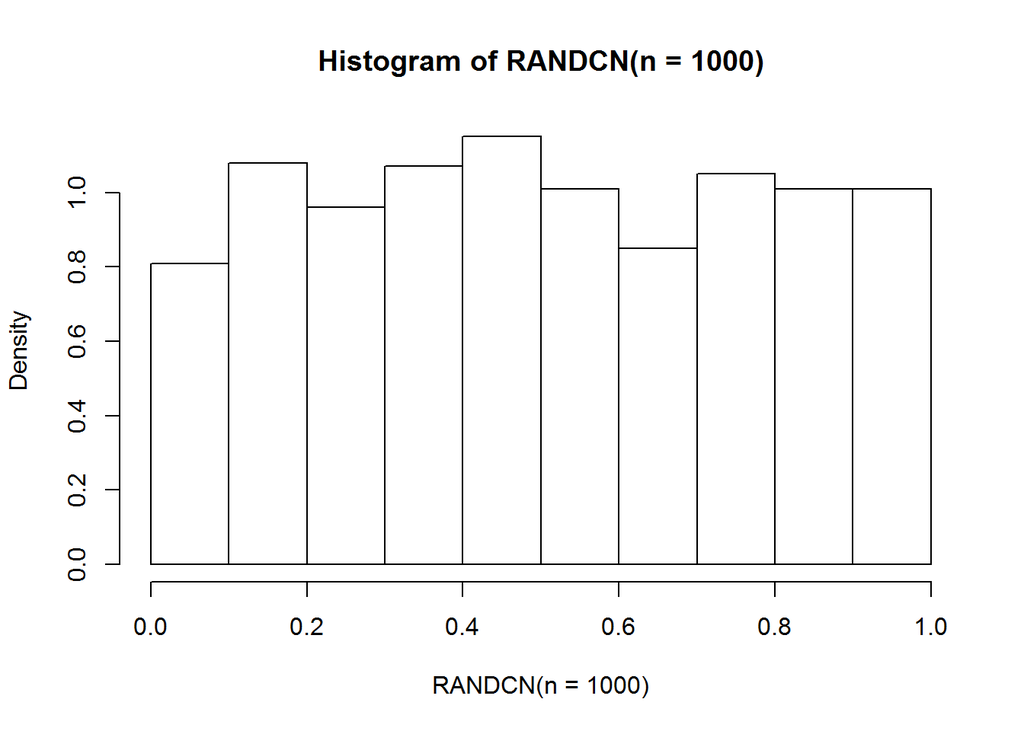

```r
hist(RANDCN(n=1000), freq = FALSE)
```

```r
#abline(h = 1,col=4,byrow = TRUE)
```

Contraste de Kolmogorov-Smirnov

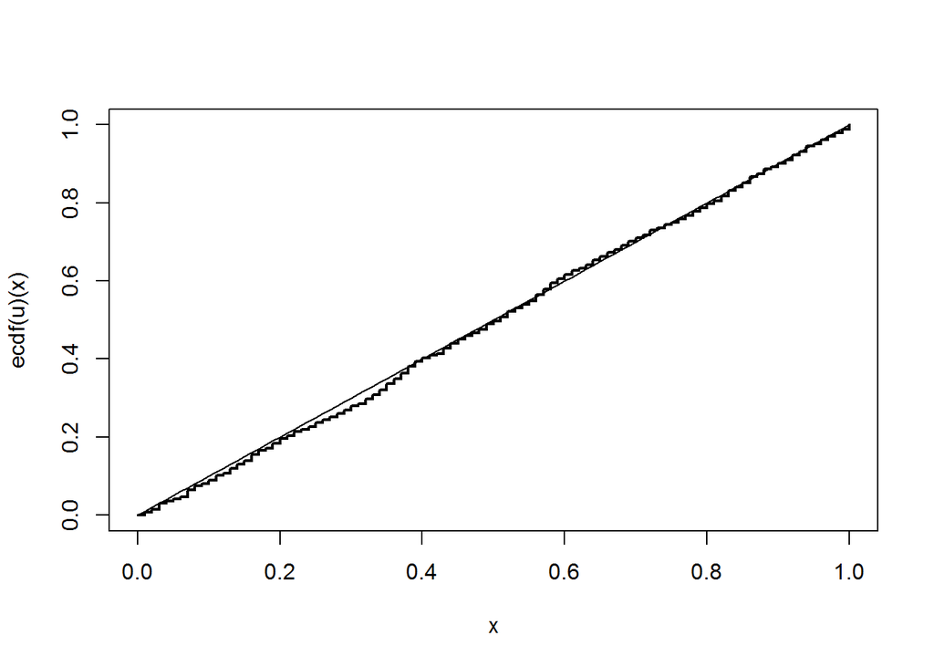

```r
u<-RANDCN(n=1000)
curve(ecdf(u)(x), type = "s", lwd = 2)
curve(punif(x, 0, 1), add = TRUE)
```

```r
ks.test(u, "punif", 0, 1)
```

```
##
##  One-sample Kolmogorov-Smirnov test
##
## data:  u
## D = 0.027244, p-value = 0.448
## alternative hypothesis: two-sided
```

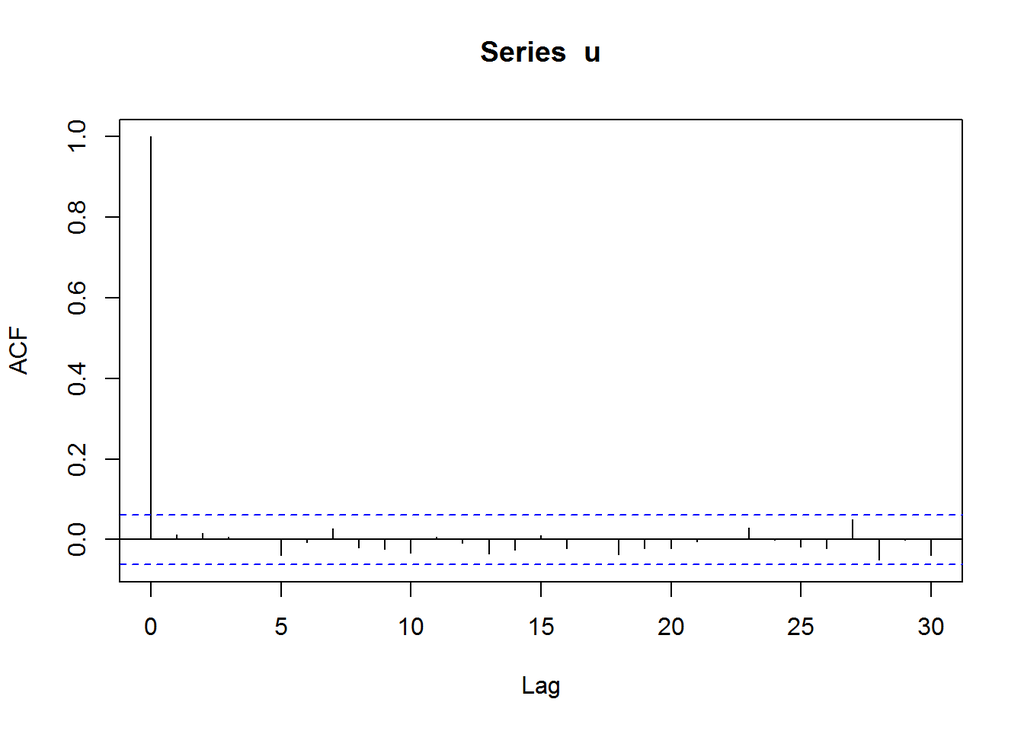

```r
u<-RANDCN(n=1000)
acf(u)
```

Se puede identificar la independencia.

$p-valor$ a las de referencia.

```r
pruebas<-500
tamano<-50
Box.test(x = u,lag = 10,type = "Ljung")
```

```
##
##  Box-Ljung test
##
## data:  u
## X-squared = 4.9265, df = 10, p-value = 0.896
```